# 4-annotated-pre-analysis-plan

```r
# this suggests that moving the needle on perpetration is effectively unsolved problem

# in general, the effects on victimization and  perpetration are larger in the rcts,
# which is encouraging (and surprising to me).

table(dat$behavior_type)
```

```
##
##      attitude     bystander   involvement  perpetration victimization
##           355            27             9            64            45
```

```r
# TODO: triple-check that thesse are right.

# scale type and delay
dat %>% split(list(.$scale_type,.$yes_delay)) %>%
  map(.f = ~robust(x = rma(yi = .x$d, vi = .x$var_d),
       cluster = .x$unique_study_id))
```

```
## $attitudes.FALSE
##
## Random-Effects Model (k = 173; tau^2 estimator: REML)
##
## tau^2 (estimated amount of total heterogeneity): 0.2147 (SE = 0.0278)
## tau (square root of estimated tau^2 value):      0.4633
## I^2 (total heterogeneity / total variability):   92.60%
## H^2 (total variability / sampling variability):  13.52
##
## Test for Heterogeneity:
## Q(df = 172) = 1565.0745, p-val < .0001
##
## Number of estimates:   173
## Number of clusters:    168
## Estimates per cluster: 1-3 (mean: 1.03, median: 1)
##
## Model Results:
##
## estimate      se¹     tval¹   df¹    pval¹   ci.lb¹   ci.ub¹
##   0.4098  0.0390   10.5180   167   <.0001   0.3329   0.4867   ***
##
## ---
## Signif. codes:  0 '***' 0.001 '**' 0.01 '*' 0.05 '.' 0.1 ' ' 1
##
## 1) results based on cluster-robust inference (var-cov estimator: CR1,
##    approx t-test and confidence interval, df: residual method)
##
##
## $behavior.FALSE
##
## Random-Effects Model (k = 20; tau^2 estimator: REML)
##
## tau^2 (estimated amount of total heterogeneity): 0.0340 (SE = 0.0193)
## tau (square root of estimated tau^2 value):      0.1845
## I^2 (total heterogeneity / total variability):   67.54%
## H^2 (total variability / sampling variability):  3.08
##
## Test for Heterogeneity:
## Q(df = 19) = 63.5102, p-val < .0001
##
```

[output cut: 55 more lines]

```
##
## Number of estimates:   125
## Number of clusters:    83
## Estimates per cluster: 1-4 (mean: 1.51, median: 1)
##
## Model Results:
##
## estimate      se¹    tval¹  df¹    pval¹   ci.lb¹   ci.ub¹
##   0.0616  0.0230   2.6727   82   0.0091   0.0157   0.1074   **
##
## ---
## Signif. codes:  0 '***' 0.001 '**' 0.01 '*' 0.05 '.' 0.1 ' ' 1
##
## 1) results based on cluster-robust inference (var-cov estimator: CR1,
##    approx t-test and confidence interval, df: residual method)
```

sum_lm() checks that don’t make it into the final paper

```r
dat %>%
  split(.$ra) %>%
  map(.f = ~sum_lm(y = d, x = se_d, dat = .))
```

```
## $`FALSE`
##             Estimate Std. Error t value Pr(>|t|)
## (Intercept)  0.16635    0.06573 2.53072  0.01186
## se_d         0.89244    0.38315 2.32923  0.02047
##
## $`TRUE`
##             Estimate Std. Error t value Pr(>|t|)
## (Intercept)  0.18346    0.08467 2.16679  0.03158
## se_d         0.20773    0.25571 0.81239  0.41765
```

```r
# how about the overall relationship between lab/field and d?
sum_lm(dat, d, lab_field)
```

```
##              Estimate Std. Error  t value Pr(>|t|)
## (Intercept)   0.30236    0.02748 11.00287  0.00000
## lab_fieldlab -0.04336    0.04302 -1.00796  0.31396
```

```r
# study type?
sum_lm(dat, d, study_design)
```

```
##                                Estimate Std. Error  t value Pr(>|t|)
## (Intercept)                     0.42385    0.03876 10.93628    0e+00
## study_designquasi-experimental -0.21411    0.05226 -4.09711    5e-05
## study_designrct                -0.17729    0.05200 -3.40950    7e-04
```

```r
# yep, meaningful relationship

# scale type?
sum_lm(dat, d, scale_type)
```

```
##                    Estimate Std. Error  t value Pr(>|t|)
## (Intercept)         0.37233    0.02404 15.49084        0
## scale_typebehavior -0.30230    0.04463 -6.77298        0
```

```r
# that is a HUGE difference

# publication status?
sum_lm(dat, d, publication_type)
```

```
##                                   Estimate Std. Error  t value Pr(>|t|)
## (Intercept)                        0.30381    0.02690 11.29535  0.00000
## publication_typegovernment report -0.31261    0.21315 -1.46663  0.14311
## publication_typedissertation      -0.04368    0.04395 -0.99390  0.32075
## publication_typeformal evaluation  0.07219    0.47357  0.15244  0.87890
```

```r
dat %>%
  filter(behavior_type == 'perpetration',
         study_design == 'rct') %>%
  sum_lm(d, se_d)
```

```
##             Estimate Std. Error t value Pr(>|t|)
## (Intercept)  0.03651    0.13236 0.27580  0.78488
## se_d         0.06008    0.34803 0.17263  0.86428
```

Correlation between attitudes and behaviors – standard errors of estimates

```r
# thank you https://stackoverflow.com/questions/16097453/how-to-compute-p-value-and-standard-error-from-correlation-analysis-of-rs-cor
cor.test.plus <- function(x) {
  list(x,
       Standard.Error = unname(sqrt((1 - x$estimate^2)/x$parameter)))
}
cor.test.plus(
  cor.test(
    x = has_both$mean_d_attitudes,
    y = has_both$mean_d_behavior))
```

```
## [[1]]
##
##  Pearson's product-moment correlation
##
## data:  has_both$mean_d_attitudes and has_both$mean_d_behavior
## t = 1.0937, df = 59, p-value = 0.2785
## alternative hypothesis: true correlation is not equal to 0
## 95 percent confidence interval:
##  -0.1149387  0.3793181
## sample estimates:
##       cor
## 0.1409621
##
##
## $Standard.Error
## [1] 0.128889
```

Different ways of assessing effect size change over time

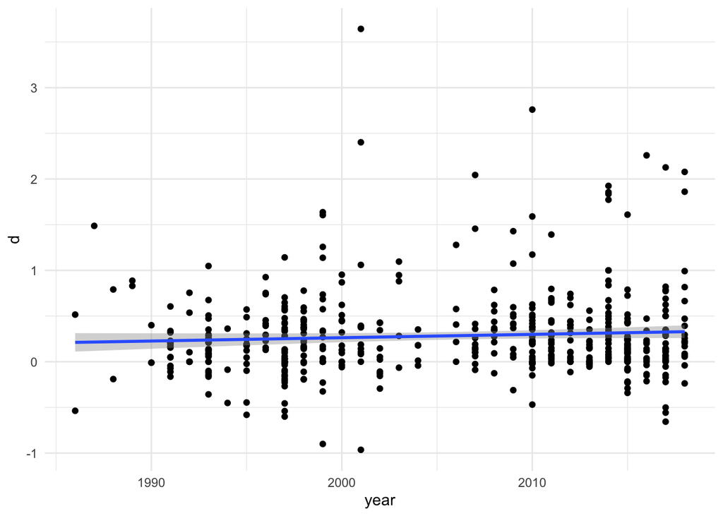

```r
dat %>% ggplot((aes(x = year, y = d))) +
  geom_point() +
  geom_smooth(method = 'lm') +
  theme_minimal()
```

```r
# basically no slope

dat %>% sum_lm(d, year)
```

```
##             Estimate Std. Error  t value Pr(>|t|)
## (Intercept) -7.02983    4.73292 -1.48530  0.13810
## year         0.00365    0.00236  1.54546  0.12287
```

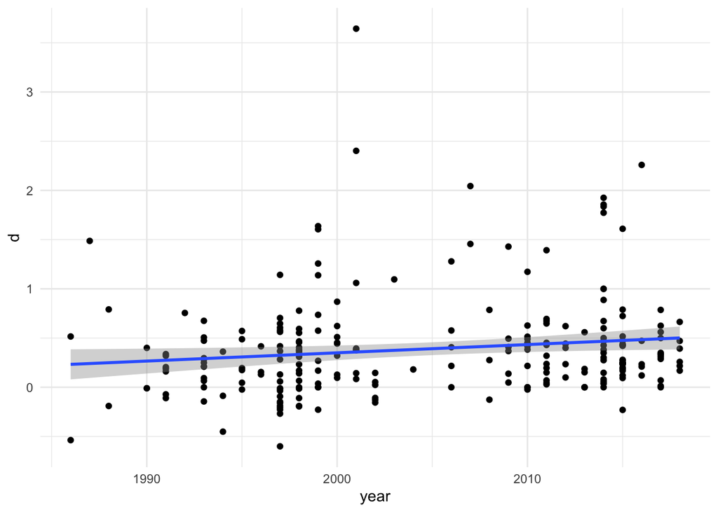

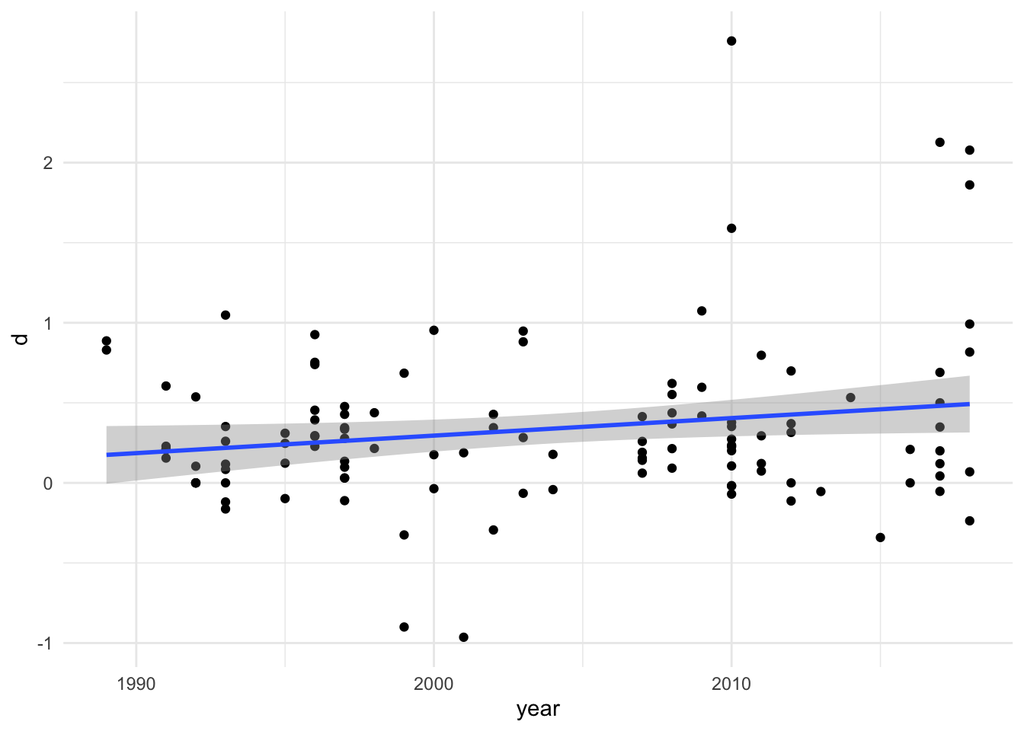

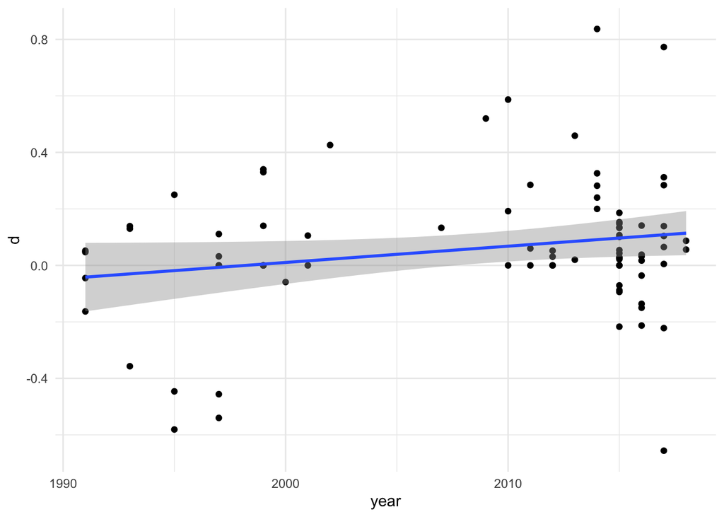

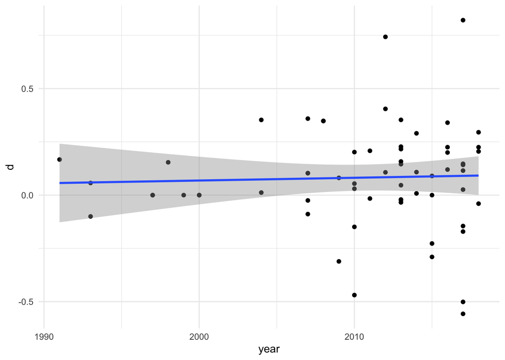

```r
dat %>% split(list(.$ra, .$scale_type)) %>%
  map(~ ggplot(data = ., mapping = aes(x = year, y = d)) +
        geom_point() +
        geom_smooth(method = 'lm') +
        theme_minimal())
```

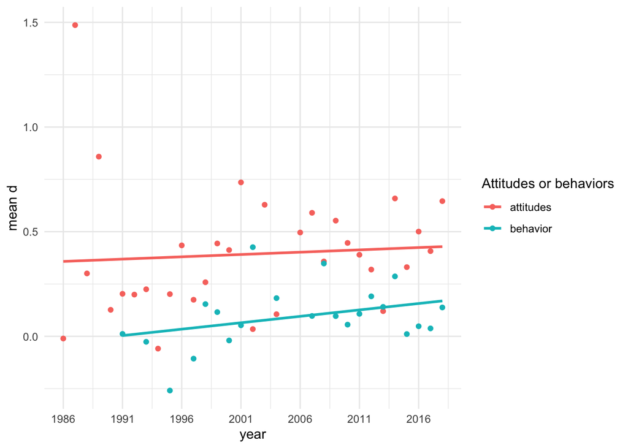

```r
# these are more or less the same results as  Anderson, L. A., & Whiston, S.C. (2005)

# visualizing how little attitudes and behavioral outcomes have changed over time
dat %>%
  group_by(year, scale_type) %>%
  summarise(mean_d = mean(d),
            mean_se_d = mean(se_d)) %>%
  ggplot(aes(x = year, y = mean_d,
             group = scale_type)) +
  geom_point(aes(color = scale_type)) +
  geom_smooth(method = 'lm', aes(color = scale_type), se = F) +
  theme_minimal() +
  scale_x_continuous(breaks = seq(1986, 2018, 5)) +
    labs(x = "year",
       y = "mean d") +
  labs(color = "Attitudes or behaviors")
```

additional ways to look at rct perp outcomes

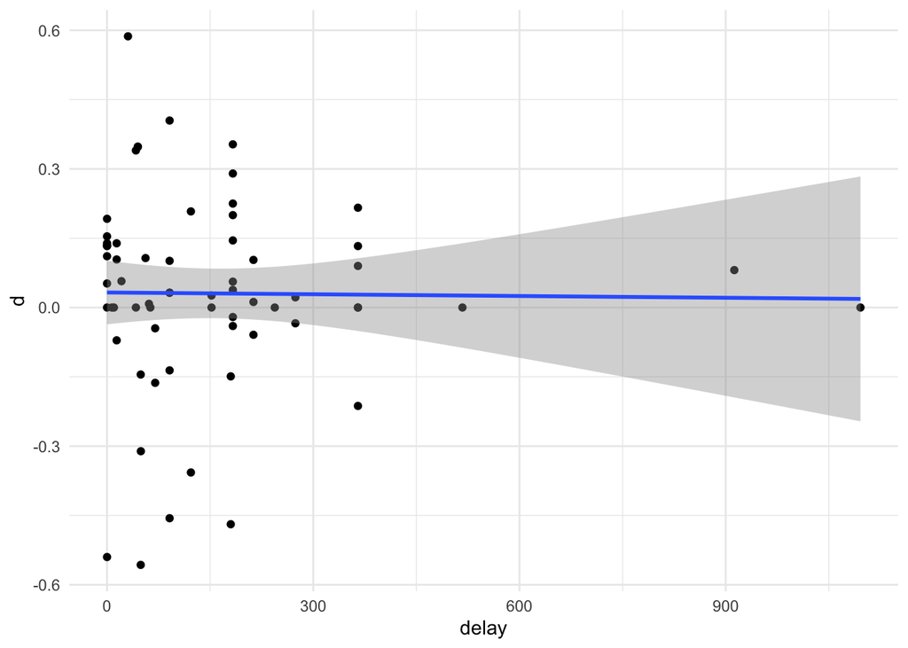

```r
# not a big difference

rct_perp %>% ggplot(mapping = aes(x = delay, y = d)) +
  geom_point() +
  geom_smooth(method = 'lm') +
  theme_minimal()
```

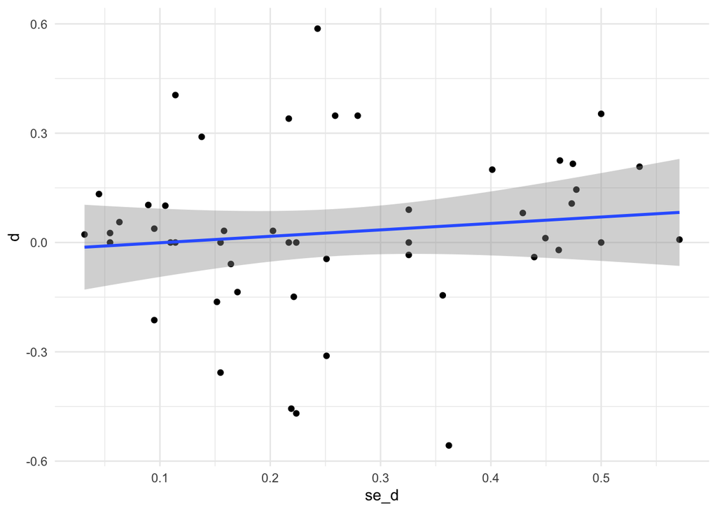

```r
rct_perp %>% filter(delay > 30) %>%
ggplot(mapping = aes(x = se_d, y = d)) +
  geom_point() +
  geom_smooth(method = 'lm') +
  theme_minimal()
```

```r
# a stronger relationship
```

### Quintile check

```r
dat %>% ungroup %>% arrange(n_t_post) %>%
  mutate(quintile = ntile(n_t_post, 5)) %>%
  group_by(unique_paper_id, intervention_name) %>%
  split(.$quintile) %>%
  map(.f = ~robust(x = rma(yi = .x$d, vi = .x$var_d),
                   cluster = .x$unique_study_id))
```

```
## $`1`
##
## Random-Effects Model (k = 100; tau^2 estimator: REML)
##
## tau^2 (estimated amount of total heterogeneity): 0.1014 (SE = 0.0257)
## tau (square root of estimated tau^2 value):      0.3184
## I^2 (total heterogeneity / total variability):   56.91%
## H^2 (total variability / sampling variability):  2.32
##
## Test for Heterogeneity:
## Q(df = 99) = 233.0001, p-val < .0001
##
## Number of estimates:   100
## Number of clusters:    73
## Estimates per cluster: 1-3 (mean: 1.37, median: 1)
##
## Model Results:
##
## estimate      se¹    tval¹  df¹    pval¹   ci.lb¹   ci.ub¹
##   0.3010  0.0427   7.0421   72   <.0001   0.2158   0.3863   ***
##
## ---
## Signif. codes:  0 '***' 0.001 '**' 0.01 '*' 0.05 '.' 0.1 ' ' 1
##
## 1) results based on cluster-robust inference (var-cov estimator: CR1,
##    approx t-test and confidence interval, df: residual method)
##
##
## $`2`
##
## Random-Effects Model (k = 100; tau^2 estimator: REML)
##
## tau^2 (estimated amount of total heterogeneity): 0.1931 (SE = 0.0348)
## tau (square root of estimated tau^2 value):      0.4395
## I^2 (total heterogeneity / total variability):   80.84%
## H^2 (total variability / sampling variability):  5.22
##
## Test for Heterogeneity:
## Q(df = 99) = 466.0899, p-val < .0001
##
```

[output cut: 83 more lines]

```
##
## Number of estimates:   100
## Number of clusters:    64
## Estimates per cluster: 1-4 (mean: 1.56, median: 1)
##
## Model Results:
##
## estimate      se¹    tval¹  df¹    pval¹   ci.lb¹   ci.ub¹
##   0.2766  0.0747   3.7012   63   0.0005   0.1273   0.4260   ***
##
## ---
## Signif. codes:  0 '***' 0.001 '**' 0.01 '*' 0.05 '.' 0.1 ' ' 1
##
## 1) results based on cluster-robust inference (var-cov estimator: CR1,
##    approx t-test and confidence interval, df: residual method)
```

```r
# just reinforces that there's no meaningful relationship between d and se; if anything the highestlargest decile seems to have the largest effect sizes
```

what about things that get tested more than once?

```r
dat %>%
  filter(intervention_name == "bringing in the bystander") %>%
  split(.$scale_type) %>%
  map(~robust(x = rma(yi = .$d,  sei = .$se_d),
              cluster = .$unique_paper_id))
```

```
## $attitudes
##
## Random-Effects Model (k = 12; tau^2 estimator: REML)
##
## tau^2 (estimated amount of total heterogeneity): 0 (SE = 0.0064)
## tau (square root of estimated tau^2 value):      0
## I^2 (total heterogeneity / total variability):   0.00%
## H^2 (total variability / sampling variability):  1.00
##
## Test for Heterogeneity:
## Q(df = 11) = 7.7344, p-val = 0.7369
##
## Number of estimates:   12
## Number of clusters:    7
## Estimates per cluster: 1-2 (mean: 1.71, median: 2)
##
## Model Results:
##
## estimate      se¹    tval¹  df¹    pval¹   ci.lb¹   ci.ub¹
##   0.2601  0.0357   7.2927    6   0.0003   0.1728   0.3474   ***
##
## ---
## Signif. codes:  0 '***' 0.001 '**' 0.01 '*' 0.05 '.' 0.1 ' ' 1
##
## 1) results based on cluster-robust inference (var-cov estimator: CR1,
##    approx t-test and confidence interval, df: residual method)
##
##
## $behavior
##
## Random-Effects Model (k = 7; tau^2 estimator: REML)
##
## tau^2 (estimated amount of total heterogeneity): 0 (SE = 0.0071)
## tau (square root of estimated tau^2 value):      0
## I^2 (total heterogeneity / total variability):   0.00%
## H^2 (total variability / sampling variability):  1.00
##
## Test for Heterogeneity:
## Q(df = 6) = 1.9000, p-val = 0.9287
##
## Number of estimates:   7
## Number of clusters:    6
## Estimates per cluster: 1-2 (mean: 1.17, median: 1)
##
## Model Results:
##
## estimate      se¹    tval¹  df¹    pval¹   ci.lb¹   ci.ub¹
##   0.1664  0.0248   6.7184    5   0.0011   0.1028   0.2301   **
##
## ---
## Signif. codes:  0 '***' 0.001 '**' 0.01 '*' 0.05 '.' 0.1 ' ' 1
##
## 1) results based on cluster-robust inference (var-cov estimator: CR1,
##    approx t-test and confidence interval, df: residual method)
```

# Everything hereonout I moved from the analysis script to here on 6-28

# study design

## Heterogeneity across designs and outcomes

### By study type:

*pap*: “Analysis of subgroups or subsets: We will compare subsets of the data according to classifications of evaluation methodology (i.e., observational vs. quasi-experimental vs. experimental methods) and of outcome measurement

*pap*: Compare the effect size of behavioral outcomes for experimental and quasi-experimental studies vs. non-experimental observational studies, both in the short- and in the long-term.”

…(i.e., general behavior indices vs. perpetration behavior, and attitudinal measurement vs. behavioral measurement).

*paper*: “The picture becomes murkier, however, when we break effect size estimates down by study design and attitudes vs. behaviors…Further, the largest behavioral effect sizes are found, on average, within randomized designs”

```r
# main body of table
dat %>%
  split(list(.$scale_type, .$study_design)) %>%
  map(.f = ~robust(x = rma(yi = .x$d, vi = .x$var_d),
       cluster = .x$unique_study_id))
```

```
## $attitudes.observational
##
## Random-Effects Model (k = 116; tau^2 estimator: REML)
##
## tau^2 (estimated amount of total heterogeneity): 0.3504 (SE = 0.0497)
## tau (square root of estimated tau^2 value):      0.5919
## I^2 (total heterogeneity / total variability):   97.43%
## H^2 (total variability / sampling variability):  38.89
##
## Test for Heterogeneity:
## Q(df = 115) = 3393.4884, p-val < .0001
##
## Number of estimates:   116
## Number of clusters:    92
## Estimates per cluster: 1-3 (mean: 1.26, median: 1)
##
## Model Results:
##
## estimate      se¹    tval¹  df¹    pval¹   ci.lb¹   ci.ub¹
##   0.5045  0.0670   7.5292   91   <.0001   0.3714   0.6376   ***
##
## ---
## Signif. codes:  0 '***' 0.001 '**' 0.01 '*' 0.05 '.' 0.1 ' ' 1
##
## 1) results based on cluster-robust inference (var-cov estimator: CR1,
##    approx t-test and confidence interval, df: residual method)
##
##
## $behavior.observational
##
## Random-Effects Model (k = 28; tau^2 estimator: REML)
##
## tau^2 (estimated amount of total heterogeneity): 0.0103 (SE = 0.0069)
## tau (square root of estimated tau^2 value):      0.1013
## I^2 (total heterogeneity / total variability):   41.54%
## H^2 (total variability / sampling variability):  1.71
##
## Test for Heterogeneity:
## Q(df = 27) = 51.3467, p-val = 0.0032
##
```

[output cut: 111 more lines]

```
##
## Number of estimates:   63
## Number of clusters:    43
## Estimates per cluster: 1-2 (mean: 1.47, median: 1)
##
## Model Results:
##
## estimate      se¹    tval¹  df¹    pval¹   ci.lb¹   ci.ub¹
##   0.1073  0.0449   2.3920   42   0.0213   0.0168   0.1979   *
##
## ---
## Signif. codes:  0 '***' 0.001 '**' 0.01 '*' 0.05 '.' 0.1 ' ' 1
##
## 1) results based on cluster-robust inference (var-cov estimator: CR1,
##    approx t-test and confidence interval, df: residual method)
```

```r
# behavior vs attitudes for the 'overall' row
dat %>%
  split(.$scale_type) %>%
  map(.f = ~robust(x = rma(yi = .x$d, vi = .x$var_d),
       cluster = .x$unique_study_id))
```

```
## $attitudes
##
## Random-Effects Model (k = 355; tau^2 estimator: REML)
##
## tau^2 (estimated amount of total heterogeneity): 0.2018 (SE = 0.0183)
## tau (square root of estimated tau^2 value):      0.4492
## I^2 (total heterogeneity / total variability):   92.57%
## H^2 (total variability / sampling variability):  13.47
##
## Test for Heterogeneity:
## Q(df = 354) = 4789.1809, p-val < .0001
##
## Number of estimates:   355
## Number of clusters:    268
## Estimates per cluster: 1-4 (mean: 1.32, median: 1)
##
## Model Results:
##
## estimate      se¹     tval¹   df¹    pval¹   ci.lb¹   ci.ub¹
##   0.3668  0.0304   12.0641   267   <.0001   0.3069   0.4266   ***
##
## ---
## Signif. codes:  0 '***' 0.001 '**' 0.01 '*' 0.05 '.' 0.1 ' ' 1
##
## 1) results based on cluster-robust inference (var-cov estimator: CR1,
##    approx t-test and confidence interval, df: residual method)
##
##
## $behavior
##
## Random-Effects Model (k = 145; tau^2 estimator: REML)
##
## tau^2 (estimated amount of total heterogeneity): 0.0250 (SE = 0.0057)
## tau (square root of estimated tau^2 value):      0.1582
## I^2 (total heterogeneity / total variability):   64.88%
## H^2 (total variability / sampling variability):  2.85
##
## Test for Heterogeneity:
## Q(df = 144) = 322.2890, p-val < .0001
##
## Number of estimates:   145
## Number of clusters:    97
## Estimates per cluster: 1-4 (mean: 1.49, median: 1)
##
## Model Results:
##
## estimate      se¹    tval¹  df¹    pval¹   ci.lb¹   ci.ub¹
##   0.0723  0.0218   3.3183   96   0.0013   0.0291   0.1156   **
##
## ---
## Signif. codes:  0 '***' 0.001 '**' 0.01 '*' 0.05 '.' 0.1 ' ' 1
##
## 1) results based on cluster-robust inference (var-cov estimator: CR1,
##    approx t-test and confidence interval, df: residual method)
```

```r
# study designs for the "overall" column
dat %>%
      split(.$study_design) %>%
      map(.f = ~robust(x = rma(yi = .x$d, vi = .x$var_d),
       cluster = .x$unique_study_id))
```

```
## $observational
##
## Random-Effects Model (k = 144; tau^2 estimator: REML)
##
## tau^2 (estimated amount of total heterogeneity): 0.3184 (SE = 0.0406)
## tau (square root of estimated tau^2 value):      0.5642
## I^2 (total heterogeneity / total variability):   96.98%
## H^2 (total variability / sampling variability):  33.15
##
## Test for Heterogeneity:
## Q(df = 143) = 3647.2830, p-val < .0001
##
## Number of estimates:   144
## Number of clusters:    99
## Estimates per cluster: 1-4 (mean: 1.45, median: 1)
##
## Model Results:
##
## estimate      se¹    tval¹  df¹    pval¹   ci.lb¹   ci.ub¹
##   0.4115  0.0575   7.1569   98   <.0001   0.2974   0.5257   ***
##
## ---
## Signif. codes:  0 '***' 0.001 '**' 0.01 '*' 0.05 '.' 0.1 ' ' 1
##
## 1) results based on cluster-robust inference (var-cov estimator: CR1,
##    approx t-test and confidence interval, df: residual method)
##
##
## $`quasi-experimental`
##
## Random-Effects Model (k = 176; tau^2 estimator: REML)
##
## tau^2 (estimated amount of total heterogeneity): 0.0901 (SE = 0.0124)
## tau (square root of estimated tau^2 value):      0.3002
## I^2 (total heterogeneity / total variability):   87.75%
## H^2 (total variability / sampling variability):  8.16
##
## Test for Heterogeneity:
## Q(df = 175) = 1562.8876, p-val < .0001
##
```

[output cut: 27 more lines]

```
##
## Number of estimates:   180
## Number of clusters:    102
## Estimates per cluster: 1-4 (mean: 1.76, median: 2)
##
## Model Results:
##
## estimate      se¹    tval¹   df¹    pval¹   ci.lb¹   ci.ub¹
##   0.2399  0.0330   7.2594   101   <.0001   0.1744   0.3055   ***
##
## ---
## Signif. codes:  0 '***' 0.001 '**' 0.01 '*' 0.05 '.' 0.1 ' ' 1
##
## 1) results based on cluster-robust inference (var-cov estimator: CR1,
##    approx t-test and confidence interval, df: residual method)
```

```r
# overall/overall text comes from overall_meta chunk

# TODO (maybe): extract the needed elements from the list and
# format it into a nice table rather than filling in table by hand?
# EDIT: I tried this with chatGPT and got very complicated code in response
# is on the backburner

# double-check Ns;
dat %>% group_by(scale_type, study_design) %>% tally()
```

```
## # A tibble: 6 × 3
## # Groups:   scale_type [2]
##   scale_type study_design           n
##   <fct>      <chr>              <int>
## 1 attitudes  observational        116
## 2 attitudes  quasi-experimental   122
## 3 attitudes  rct                  117
## 4 behavior   observational         28
## 5 behavior   quasi-experimental    54
## 6 behavior   rct                   63
```

*paper* (footnote): “…In keeping with the consistency between available meta-analyses’ estimates, we also observe a small, statistically insignificant relationship between effect size and year of publication”

```r
dat %>% sum_lm(y = d, x = year)
```

```
##             Estimate Std. Error  t value Pr(>|t|)
## (Intercept) -7.02983    4.73292 -1.48530  0.13810
## year         0.00365    0.00236  1.54546  0.12287
```

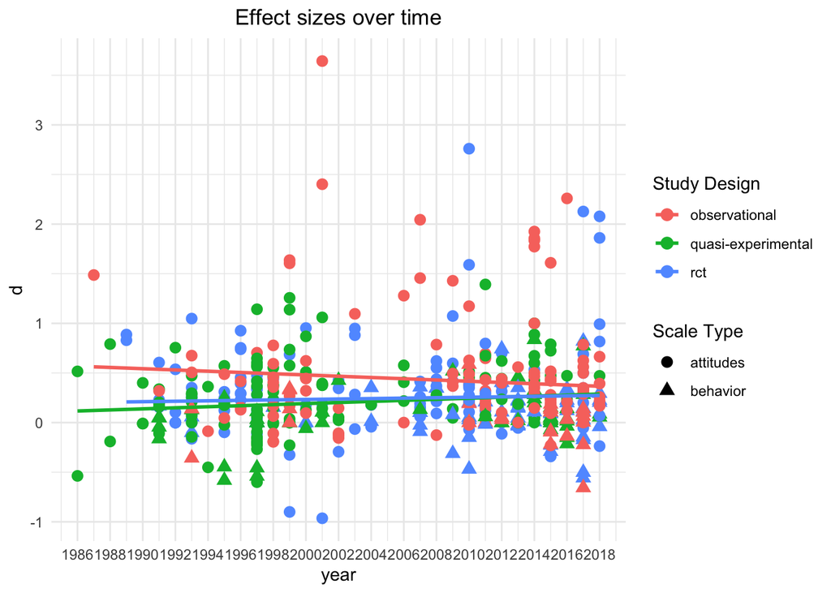

```r
# this graph isn't in the paper but making sure there's no obvious relationship:
dat %>%
  ggplot(aes(x = year, y = d, color = study_design)) +
  geom_point(aes(shape = scale_type), size = 3) +
  geom_smooth(aes(group = study_design), method = "lm", se = FALSE) +
  scale_x_continuous(breaks = seq(1986, 2018, by = 2)) +
  theme_minimal() +
  labs(color = "Study Design", shape = "Scale Type") +
  guides(color = guide_legend(order = 1), shape = guide_legend(order = 2)) +
  ggtitle('Effect sizes over time') +
  theme(plot.title = element_text(hjust = 0.5)) +
  scale_shape_manual(values = c("attitudes" = 16, "behavior" = 17))
```